# Flight Price Analysis

Ayan Jhaveri

## Data Preparation

### Loading and Cleaning Data

```r
# Load necessary libraries
library(dplyr)

# Load the dataset
data <- read.csv("D:/1_BU/Fundamental of ML/Term Project/flight_data.csv")

colnames(data)[colnames(data) == "duration"] <- "flight_duration"
# Remove missing values
data <- na.omit(data)

# Remove outliers based on price
Q1 <- quantile(data$price, 0.25)
Q3 <- quantile(data$price, 0.75)
IQR_value <- Q3 - Q1
lower_bound <- Q1 - 1.5 * IQR_value
upper_bound <- Q3 + 1.5 * IQR_value
data <- subset(data, price >= lower_bound & price <= upper_bound)

# Drop unwanted columns
data <- data %>%
  select(-flight, -source_city, -destination_city)
```

## 1.Duration and Price Relation

### Scatter Plot and Correlation

This section explores the relationship between flight duration and price using a scatter plot and correlation analysis.

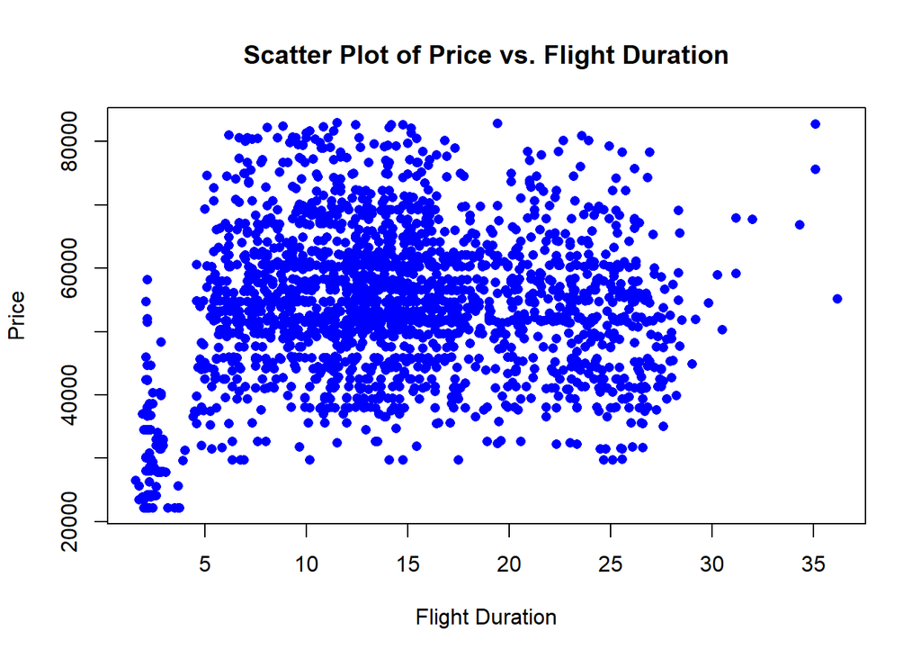

```r
# Scatter plot of Price vs. Flight Duration
plot(data$flight_duration, data$price,
     main = "Scatter Plot of Price vs. Flight Duration",
     xlab = "Flight Duration",
     ylab = "Price",
     col = "blue",
     pch = 16)
```

```r
# Calculate correlation coefficient
cor_coefficient <- cor(data$flight_duration, data$price)

# Perform correlation test
cor_test_result <- cor.test(data$flight_duration, data$price)
print(cor_test_result)
```

```
##
##  Pearson's product-moment correlation
##
## data:  data$flight_duration and data$price
## t = 11.49, df = 3250, p-value < 2.2e-16
## alternative hypothesis: true correlation is not equal to 0
## 95 percent confidence interval:
##  0.1643263 0.2303892
## sample estimates:
##       cor
## 0.1975821
```

### Linear Regression

```r
# Linear regression model
linear_model <- lm(price ~ flight_duration, data = data)
intercept <- coef(linear_model)[1]
slope <- coef(linear_model)
print(paste("Equation of the line: Price =", round(intercept, 2), "+", round(slope, 2), " * Duration"))
```

```
## [1] "Equation of the line: Price = 47778.16 + 47778.16  * Duration"
## [2] "Equation of the line: Price = 47778.16 + 347.59  * Duration"
```

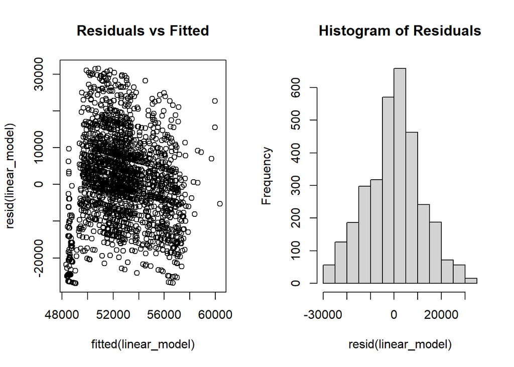

```r
# Checking assumptions
par(mfrow=c(1,2))
plot(fitted(linear_model), resid(linear_model), main="Residuals vs Fitted")
hist(resid(linear_model), main="Histogram of Residuals")
```

The p-value for duration is less than 0.05 , we can reject null hypothesis and infer that duration of the flight has a significant linear relationship with the price. As the duration of the flight increases, the price tends to increase by an average of 347.59 INR.

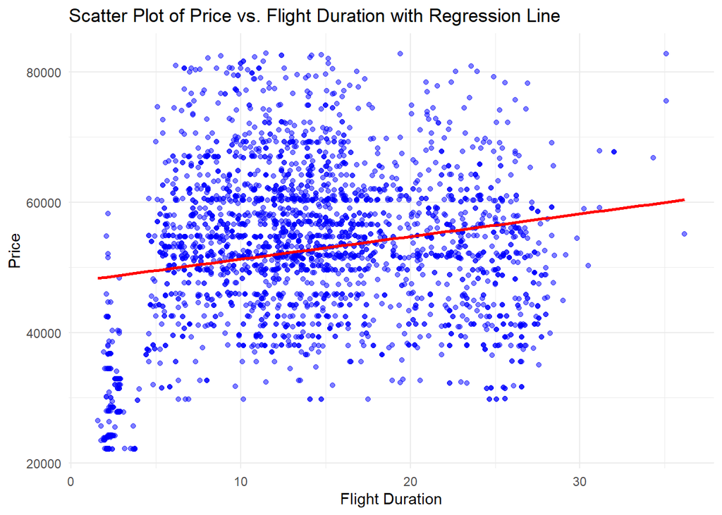

## 2.Stops vs. Price

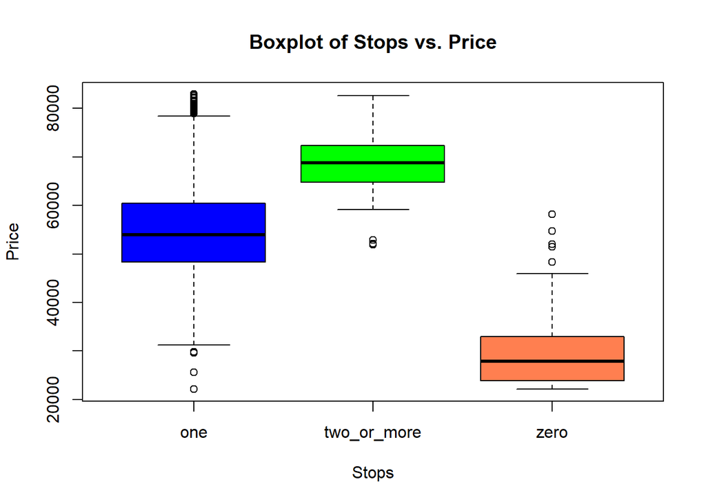

```r
# Boxplot of Stops vs Price
boxplot(price ~ stops, data = data,
        main = "Boxplot of Stops vs. Price",
        xlab = "Stops",
        ylab = "Price",
        col = c("blue", "green", "coral"))
```

### ANOVA TEST

```r
# Convert stops to factor and check if it's a factor
data$stops = as.factor(data$stops)

m = aov(data$price ~ data$stops, data = data)
summary(m)
```

```
##               Df    Sum Sq   Mean Sq F value Pr(>F)
## data$stops     2 1.413e+11 7.064e+10   713.1 <2e-16 ***
## Residuals   3249 3.219e+11 9.907e+07
## ---
## Signif. codes:  0 '***' 0.001 '**' 0.01 '*' 0.05 '.' 0.1 ' ' 1
```

```r
# Pairwise t-test for Stops vs. Price
pairwise.t.test(data$price, data$stops, p.adjust = 'none')
```

```
##
##  Pairwise comparisons using t tests with pooled SD
##
## data:  data$price and data$stops
##
##             one    two_or_more
## two_or_more <2e-16 -
## zero        <2e-16 <2e-16
##
## P value adjustment method: none
```

With a 95% confidence level, we can infer significant differences in mean prices among flights with varying numbers of stops. So, the number of stops does influence the price of the flight.

### Mean Prices by Stops

```
## # A tibble: 3 × 2
##   stops       mean_price
##   <fct>            <dbl>
## 1 one             54232.
## 2 two_or_more     68757.
## 3 zero            29658.
```

### 3. Effect Of Airline and Days Left on Price

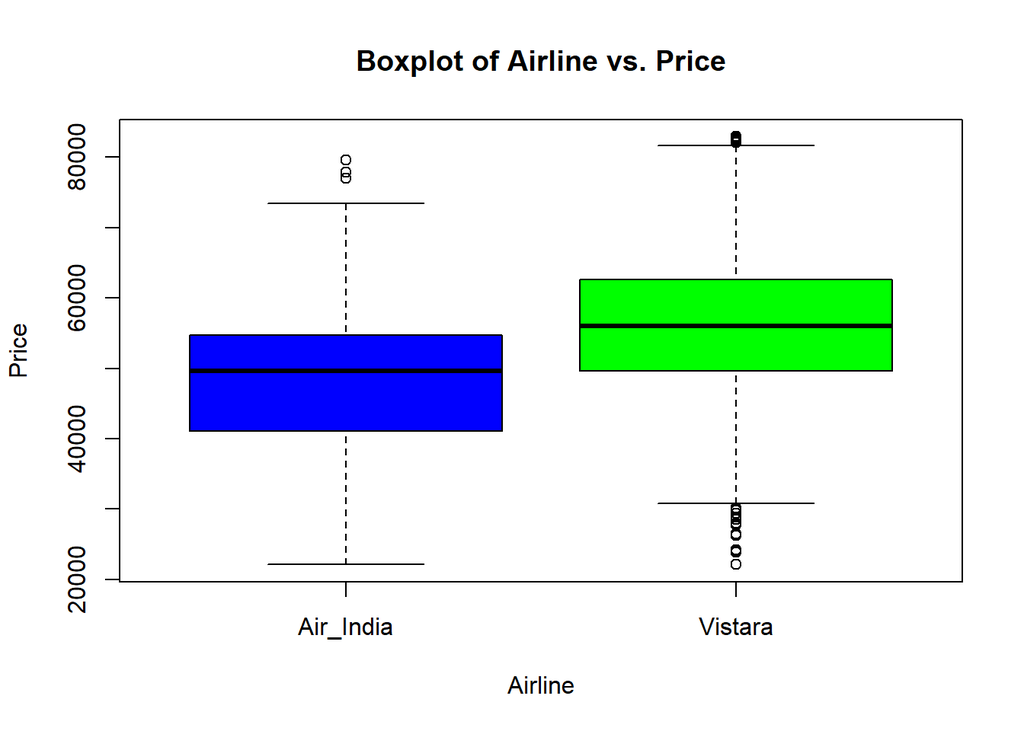

```r
# Boxplot of Airline vs Price
boxplot(price ~ airline, data = data,
        main = "Boxplot of Airline vs. Price",
        xlab = "Airline",
        ylab = "Price",
        col = c("blue", "green"))
```

```r
# Convert airline to factor and check if it's a factor
data$airline = as.factor(data$airline)

# ANOVA test for Airline vs Price
m = aov(data$price ~ data$airline, data = data)
summary(m)
```

```
##                Df    Sum Sq   Mean Sq F value Pr(>F)
## data$airline    1 4.769e+10 4.769e+10     373 <2e-16 ***
## Residuals    3250 4.155e+11 1.278e+08
## ---
## Signif. codes:  0 '***' 0.001 '**' 0.01 '*' 0.05 '.' 0.1 ' ' 1
```

```r
# ANCOVA (Airline and Days Left) test
library(car)
Anova(lm(data$price ~ data$airline + data$days_left), type = 3)
```

```
## Anova Table (Type III tests)
##
## Response: data$price
##                    Sum Sq   Df  F value    Pr(>F)
## (Intercept)    1.2587e+12    1 9918.083 < 2.2e-16 ***
## data$airline   4.8450e+10    1  381.771 < 2.2e-16 ***
## data$days_left 3.1476e+09    1   24.802 6.684e-07 ***
## Residuals      4.1233e+11 3249
## ---
## Signif. codes:  0 '***' 0.001 '**' 0.01 '*' 0.05 '.' 0.1 ' ' 1
```

Airline has a significant impact on flight prices, and this effect persists even when considering the influence of ‘days_left’. Both the choice of airline and the number of days left until departure contribute to the variability in flight prices.

## 4. Effect Of Departure and Arrival Time on Price

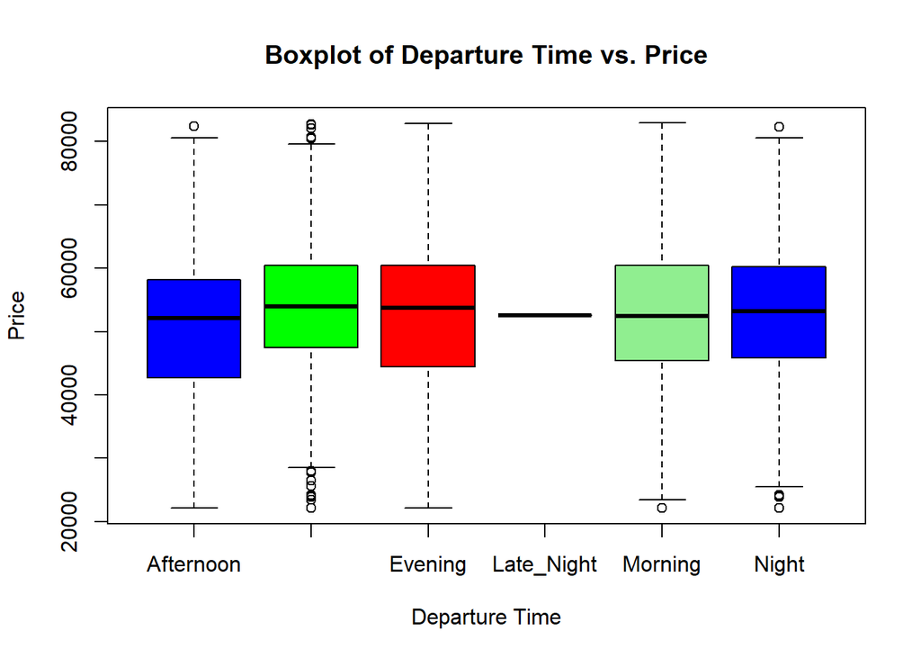

```r
# Boxplot of Departure Time vs Price
boxplot(price ~ departure_time, data = data,
        main = "Boxplot of Departure Time vs. Price",
        xlab = "Departure Time",
        ylab = "Price",
        col = c("blue", "green", "red", "lightblue", "lightgreen"))
```

```r
library(car)
# Convert departure_time to factor
data$departure_time = as.factor(data$departure_time)
data$arrival_time = as.factor(data$arrival_time)

# Two-way ANOVA for Departure Time and Arrival Time vs Price

two_way_model = lm(price ~ departure_time + data$arrival_time , data = data)
Anova(two_way_model, type = 3)
```

```
## Anova Table (Type III tests)
##
## Response: price
##                       Sum Sq   Df   F value    Pr(>F)
## (Intercept)       4.8653e+11    1 3494.1006 < 2.2e-16 ***
## departure_time    1.5688e+09    5    2.2534    0.0466 *
## data$arrival_time 1.0634e+10    5   15.2746 7.239e-15 ***
## Residuals         4.5129e+11 3241
## ---
## Signif. codes:  0 '***' 0.001 '**' 0.01 '*' 0.05 '.' 0.1 ' ' 1
```

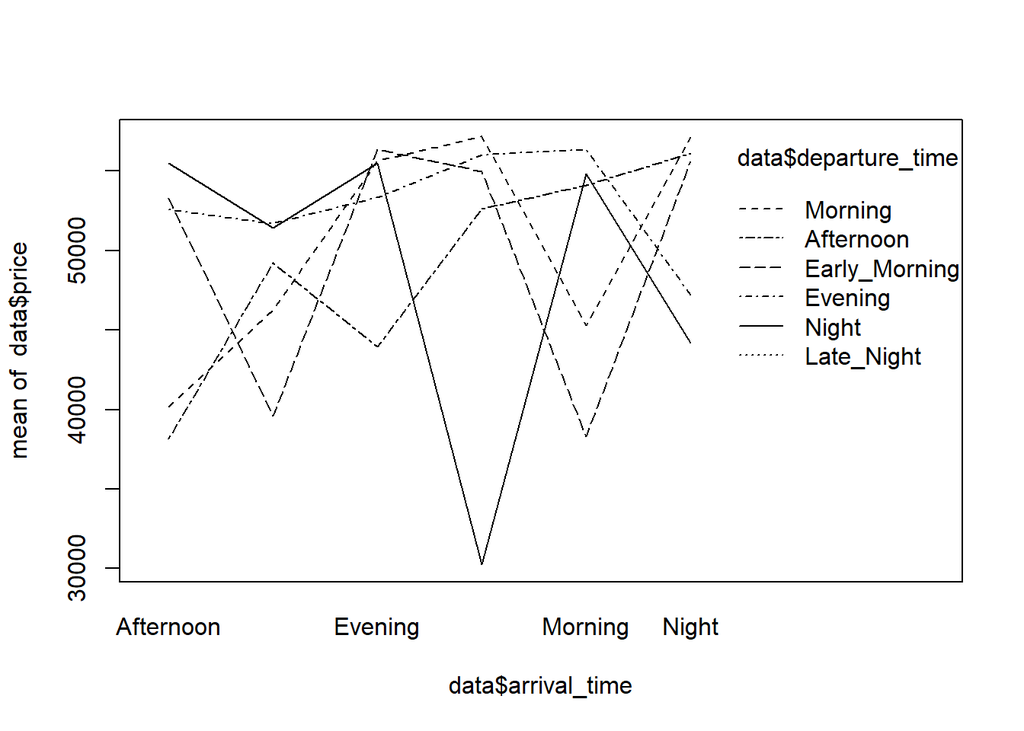

```r
# Interaction plot for Departure and Arrival Time
interaction.plot(data$arrival_time, data$departure_time, data$price)
```

```r
# Stratifying data by arrival time and performing individual ANOVA
arrival_levels <- levels(data$arrival_time)

perform_anova_summary <- function(level) {
  subset_data <- subset(data, arrival_time == level)
  print(paste("Summary for ANOVA -", level))
  print(summary(aov(price ~ departure_time, data = subset_data)))
  print("----")
}

lapply(arrival_levels, perform_anova_summary)
```

```
## [1] "Summary for ANOVA - Afternoon"
##                 Df    Sum Sq   Mean Sq F value Pr(>F)
## departure_time   4 1.947e+10 4.867e+09   47.94 <2e-16 ***
## Residuals      425 4.314e+10 1.015e+08
## ---
## Signif. codes:  0 '***' 0.001 '**' 0.01 '*' 0.05 '.' 0.1 ' ' 1
## [1] "----"
## [1] "Summary for ANOVA - Early_Morning"
##                 Df    Sum Sq   Mean Sq F value  Pr(>F)
## departure_time   4 1.991e+09 497788126   4.623 0.00164 **
## Residuals      123 1.325e+10 107686188
## ---
## Signif. codes:  0 '***' 0.001 '**' 0.01 '*' 0.05 '.' 0.1 ' ' 1
## [1] "----"
## [1] "Summary for ANOVA - Evening"
##                 Df    Sum Sq   Mean Sq F value Pr(>F)
## departure_time   4 1.129e+10 2.821e+09   24.08 <2e-16 ***
## Residuals      873 1.023e+11 1.172e+08
## ---
## Signif. codes:  0 '***' 0.001 '**' 0.01 '*' 0.05 '.' 0.1 ' ' 1
## [1] "----"
## [1] "Summary for ANOVA - Late_Night"
##                Df    Sum Sq   Mean Sq F value   Pr(>F)
## departure_time  4 4.190e+09 1.048e+09   24.09 3.48e-12 ***
## Residuals      64 2.783e+09 4.349e+07
## ---
## Signif. codes:  0 '***' 0.001 '**' 0.01 '*' 0.05 '.' 0.1 ' ' 1
## [1] "----"
## [1] "Summary for ANOVA - Morning"
##                 Df    Sum Sq   Mean Sq F value Pr(>F)
## departure_time   5 2.582e+10 5.165e+09   46.59 <2e-16 ***
## Residuals      731 8.103e+10 1.108e+08
## ---
## Signif. codes:  0 '***' 0.001 '**' 0.01 '*' 0.05 '.' 0.1 ' ' 1
## [1] "----"
## [1] "Summary for ANOVA - Night"
##                  Df    Sum Sq   Mean Sq F value Pr(>F)
## departure_time    4 2.295e+10 5.738e+09   46.27 <2e-16 ***
## Residuals      1005 1.246e+11 1.240e+08
## ---
## Signif. codes:  0 '***' 0.001 '**' 0.01 '*' 0.05 '.' 0.1 ' ' 1
## [1] "----"
```

[output not shown]